# Daily Turkish Pre-Market Pressure Index

2020-11-19

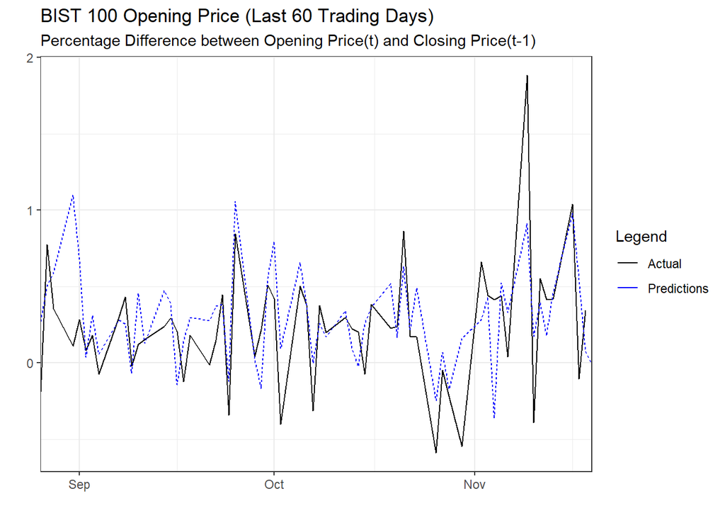

This pre-market pressure index is designed to be a predictor for the percentage difference between previous day’s closing price and current day’s opening price by using three types of pre-market data:

1. iShares MSCI Turkey ETF,
2. USDTRY index[^1],
3. Asian Emerging Markets Stock Opening Index.[^2],

This pre-market pressure index is constructed using a random forest algorithm[^3]. The index data can be downloaded here

[interactive chart not shown]

Here is the code in to produce the above plotly figure (will appear in a minute):

```r
library("plotly") #animated graph
library("widgetframe") #frame package

index <- read.csv("https://www.soybilgen.com/files/TRYPMPIindex.csv", stringsAsFactors = F)
index$Date <- as.Date(index$Date, "%Y-%m-%d")

fig <- plot_ly(index, x = ~Date)
fig <- fig %>% add_trace(y = ~Index, name = 'Pre-Market Pressure Index',type = 'scatter', mode = 'lines',color = I('black'))
fig <- fig %>% add_trace(y = ~iShares, name = 'iShares MSCI Turkey ETF', type = 'scatter', mode = "lines",
                         line = list(color = 'rgb(214, 39, 40)', width = 0, dash = 'solid', shape= "linear"),
                         fill = 'tozeroy', fillcolor='rgba(214, 39, 40, 0.5)',hoveron = 'points')
fig <- fig %>% add_trace(y = ~AsianEMIndex, name = 'Asian EM Stock Openings', type = 'scatter', mode = "lines",
                         line = list(color = 'rgb(127, 127, 127)', width = 0, dash = 'solid', shape= "linear"),
                         fill = 'tozeroy', fillcolor='rgba(127, 127, 127, 0.5)',hoveron = 'points')
fig <- fig %>% add_trace(y = ~FXIndex, name = 'USDTRY index', type = 'scatter', mode = "lines",
                         line = list(color = 'rgb(255, 199, 38)', width = 0, dash = 'solid', shape= "linear"),
                         fill = 'tozeroy', fillcolor='rgba(255, 199, 38, 0.5)',hoveron = 'points')
fig <- fig %>% rangeslider()
fig <- fig %>% layout(xaxis = list(title = ""))
fig <- fig %>% layout(yaxis = list(title = ""))
fig <- fig %>% layout(legend = list(orientation = 'h'))
fig <- fig %>% layout(legend = list(x = 0, y = -0.5))
fig <- fig %>% layout(title = "<b>Pre-Market Pressure Index</b>")
```

[^1]: The index includes changes in USDTRY and USDTRY implied volatility between the close of the Turkish Market and the pre-opening of the Turkish Market. The weight is calculated using principal component analysis.
[^2]: The index includes opening gaps of the Malaysia FTSE Bursa KLCI Index, the Thailand SET Composite Index, the Philippine PSEI Index, the Vietnam HSX Index, the Indian Nifty 50 Index
[^3]: We omit the BIST 100 opening on 2020-02-28 due to the very high volatility on that date.